# Airbnb_Austin_PredictionAnalysis

Eszter Diamant

2021 02 02

## Introduction

The aim of this analysis to determine a potential price for a company operating small and mid-size apartments hosting 2 to 6 guests. The company would like to have an insight for the current prices on the market for which an airbnb dataset was implemented located in Austin, Texas [Link for Austin dataset](http://insideairbnb.com/get-the-data.html). The data was collected on 18th of December in 2020 that may influence the analysis deeply considering the current pandemic situation. During the analysis, there will be a brief description of variable handling and preparations including the classification and cleaning that will be followed by the creation of different predicting models. In order to check the external validity of the prediction models, a cross validation will be implemented. In the end, a diagnostic will be implemented to test whether the chosen model is better than the second best model or it is over-fitted.

## Variables:

To begin with, in order to determine the predicted values, in this case the prices, several descriptive variables were applied. Only those data are considered that are for apartments. In the following section, these variables detailed how they were cleaned and handled. In the below histograms, the cleaned variables are presented for the following section.

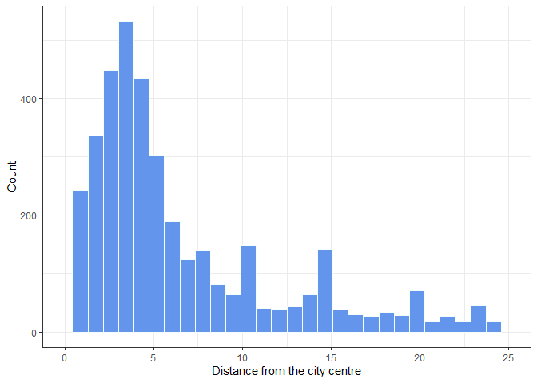

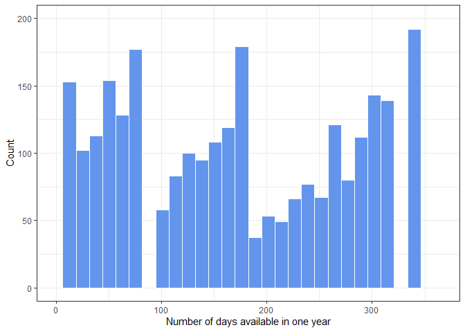

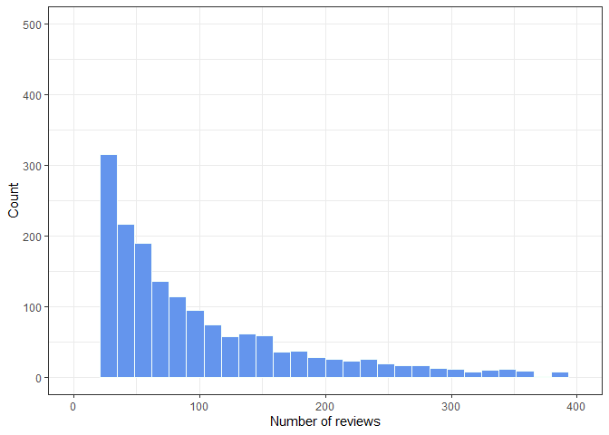

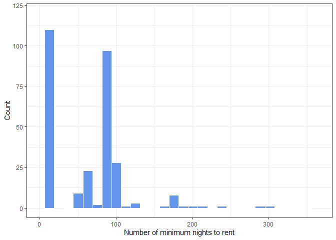

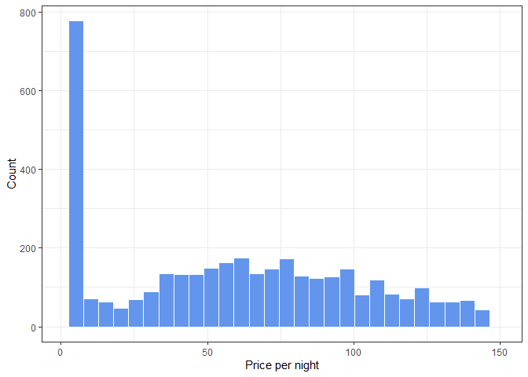

### Prices:

[output not shown]

### Distance:

The distance were not given in the original dataset, therefore it was calculated by the longitudes and latitudes of the listings. It measures the distance from the city center in kilometers. After checking a basic correlation between the prices and distance, it was determined that until 15 km, the prices decrease but after that, they follow an increasing pattern. Therefore, a binary variable was created which give 1 if it is closer than 15 km and 0 if not. As you can see on the below table that on average, the distance is around 7 km.

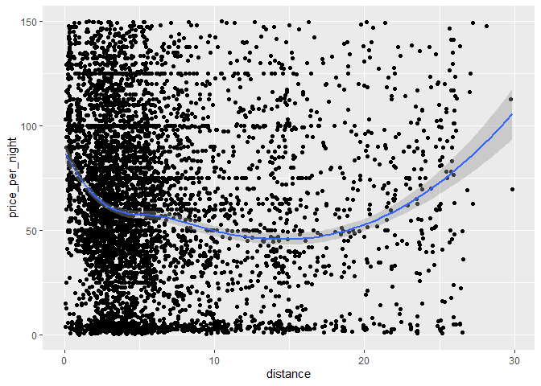

### Reviews:

There are two different variable for review measurement, they are the number of reviews and reviews per month. They are considered a potentially good descriptive values but due to the high number of reviews per month, it might contain some risk in the analysis. On the other hand, in order to see how the number of reviews may influence the predicted price, a binary variable was created which gives 1 if it exceeds 100 and 0 otherwise. In the dataset, the reviews are around 11 as the median also suggests.

### Availability:

As the final main variable that was used for the analysis is the availability of the apartments in a year. Because it measures in days for only one year, those were dropped which equaled to zero or exceeded 365. Furthermore, after checking the basic descriptives and the correlation of the availability, a final binary variable was determined that is 1 if exceeds 200 days, otherwise, it is zero. By this, the company can see how the availability may influence the pricing.

|  | Min. | 1st Qu. | Median | Mean | 3rd Qu. | Max. |
| --- | --- | --- | --- | --- | --- | --- |
| Distance | 0.088 | 2.7 | 4.33 | 6.71 | 8.84 | 29.9 |
| Days available in one year | 1.000 | 85.0 | 201.00 | 202.70 | 327.00 | 365.0 |
| Number of reviews | 0.000 | 1.0 | 11.00 | 47.99 | 57.00 | 856.0 |
| Minumum Nights for rent | 1.000 | 2.0 | 2.00 | 13.79 | 30.00 | 500.0 |

## Prediction Model

The main focus of the prediction model to determine a potential price for the company when they enter the new apartments on the market. However, the prediction analysis contains significant risks that may end in disaster. The model may not capture all of the values which is measured by the prediction error. Therefore, one of the main focus of the model choice is based on the RMSE (i.e. root of Mean Squared Error) that is an indicator of loss functions. The MSE defines the mean value for the best predictor. The lower the value the better. On the other hand, the risk of over-fitting also stands for the analysis, therefore after choosing the models, a cross-validation is implemented to check external validity.

### Lasso

The LASSO is a regression analysis method that performs both variable selection and regularization in order to enhance the prediction accuracy and interpretability of the resulting statistical model. This method was used to determine which variables are better for the analysis.

### Models and Cross Validation

For the main part of the analysis, 4 models were created. The first one only includes the distance as a descriptive variable, the second adds the neighbourhood and availability, the third the number of reviews and reviews per month and the final also includes all of the binary variables. As it was mentioned, these variables were chosen based on the Lasso. After defining the models, in order to choose the best one, a 5-fold cross validation, in which the holdout set was 30% of the whole dataset, was implemented which resulted in the following outcomes:

rmse_test

rmse_train

model_name

model_pretty_name

nvars

r2

BIC

31.9

31.9

modellev1

1

0.028

25020

30.9

30.8

modellev2

2

0.088

24863

28.3

28.3

modellev3

4

0.096

17870

28.3

28.2

modellev4

8

0.103

17888

Cross-validation is a model validation techniques for assessing how the results of a statistical analysis will generalize to an independent data set. By this, the risk of over-fitting can be evaluated and the the potentially best model can be picked for prediction. Based on the RMSE values and BIC (i.e. a criterion for model selection among a finite set of models), the third model can be picked as the potentially best model. The decision is based on that the RMSE do not differ significantly between the test and holdout set, however, this BIC is a little bit lower than the BIC of the forth model that may indicate a higher risk of bad prediction. In other words, the lower the RMSE and BIC the better, so, if the RMSE of the training set exceeds the holdout set RMSE, it may indicate a over-fitted model.

## Summary and Suggestions

###### Github Repository:

The code availale in the following link: [Github](https://github.com/DiamantEszter97/CEU-Data-Analysis-3-Assignments)